# Evaluation of 20 enset (*Ensete ventricosum*) landraces for response to *Xanthomonas vasicola* pv. *musacearum* infection

## 5.3 Post hoc analysis of disease index

Here function lsmeanLT from lmer package to extract means with their confidence interval. Then multiple comparison of landrace for disease index can be carried using general linear hypotheses (glht)and multiple comparisons for parametric models from multicomp package. The result adjusted to letter display for difference among landrace using compact letter display (cld) function. ggplot2 used to plot the result combining with original disease index data.

```r
di_lsmeansLT=lsmeansLT(disease_lmer,test.effs="landrace")#lsmeansLT calculates Least Squares Means and Confidence Intervals for the factors of a fixed part of mixed effects model of lmer object

di_lsmeansLT<-as.data.frame(di_lsmeansLT)[,-1]
rownames(di_lsmeansLT) <- NULL #remove row names containing duplicates of landrace lists

library (dplyr)
di_lsmeansLT <- di_lsmeansLT %>% mutate_if(is.numeric, funs(round(., 2)))#round data.frame to two digist using dplyr

##carry out mean separation and adjust for compact letter desply (cld)###
cld_di_lmer <- cld(glht(disease_lmer, linfct = mcp(landrace = "Tukey")), test = adjusted("holm"))###Save letters
cld_di_lmer <- cbind(levels(enset_xvm_long$landrace),cld_di_lmer$mcletters$Letters) ###bind letters to columns of respective landraces
cld_di_lmer <- data.frame(cld_di_lmer)#formatextracted cld with landraces from mean separation to data.frame
colnames(cld_di_lmer) <- c("landrace","di_let")###Name columns
rownames(cld_di_lmer) <- NULL #remove repeated rownames
di_lmer_cld <- cbind(di_lsmeansLT,cld_di_lmer[,2]) #combine extracted mean data from lmer using lsmeansLT and dataframe of letters from cld
rownames(di_lmer_cld) <- NULL #remove repeated rownames
colnames(di_lmer_cld) <- c("landrace", "mean", "Stand_Error", "DF", "t-value", "lower", "upper", "p-value", "di_let")# rename column of combined orinal data.
di_lmer_cld <- as.data.frame(di_lmer_cld) #Coerce data containing means with confidence interval and letter display to dataframe
di_lmer_cld <- di_lmer_cld[order(di_lmer_cld$mean),]# reorder by mean value to cheat ggplot
di_lmer_cld$landrace<-factor(di_lmer_cld$landrace,levels=di_lmer_cld$landrace)# put factors in level
di_long_cld <- left_join(enset_xvm_long,cld_di_lmer,by="landrace",copy=T) ###Add letter information to raw data - disease index
```

## 5.4 Ploting disease index lmer

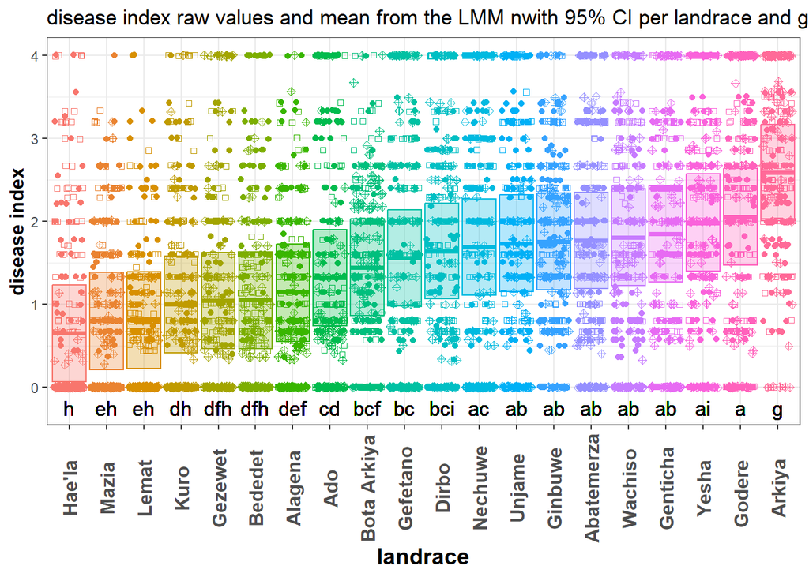

```r
di_long_cld_copy <- di_long_cld
di_long_cld_copy <- di_long_cld_copy[order(di_long_cld_copy$di),]# reorder by mean value to cheat ggplot
di_lmer_cld=di_lmer_cld[order(di_lmer_cld$mean),]# reorder by mean value to cheat ggplot
di_lmer_cld$landrace<-factor(di_lmer_cld$landrace, levels = di_lmer_cld$landrace)# put factors in level
di_long_cld$block <- as.factor(di_long_cld$block)
####Generate plot of mean+confidence interval of disease index with significance letters and raw data as jittered points#
ggplot(aes(x=landrace, y=di, color=landrace),data=di_long_cld) + ###Plot the origial disease index data
  geom_crossbar(data = di_lmer_cld, aes(x = landrace, y = mean, ymin = lower, ymax = upper,fill=landrace), alpha=0.3) +
    geom_jitter(aes(shape=block)) + ###with jitter overplotted, symbol shape defined by block
  scale_shape_manual(values=c(9, 19, 22,23))+
  geom_text(aes(x=landrace, y=-0.25, label=di_let,size=10),color="black", data=di_long_cld) + ###Get the letters from di_long_cld
  #and write those to position y=-3
  labs(y="disease index") + #Y-Axis label
  ggtitle("disease index raw values and mean from the LMM\ nwith 95% CI per landrace and grouping letters") +#Title
 theme_bw()+
  theme(axis.title.x = element_text(face="bold", size=14), axis.text.x  =  element_text(angle=90, vjust=0.5, size=12,face = "bold"))+
  theme(axis.title.y= element_text(size = 12,face = "bold"))+
  theme(legend.position="none")
```

# 6. Analysis of apparent infection rate (AIR)

Apparent infection rate which is the speed at which an epidemic develops [(Meena et al., 2011)](https://www.tandfonline.com/doi/abs/10.1080/03235400903345281), was calculated as the slope of disease index development.

Disease index data though best fits to mixed model we could not able to extract rate of disease development value for each landrace using mixed model approach. Instead we considered linear development of disease and used disease index as function of time and intercept for analysis (i.e y=ax+b, where y is disease index, x is time and b is intercept). In this way a function that goes through each landrace is constructed to extract the slop of disease index from each landrace.

```r
slop_data=di_wk# take copy of the original wide formated data for analysis

slop_api<-numeric(600)
time<-c(21,35,50,65,80,95,110,125,140,155)# disease evaluation days after inoculation of the pathogen.
for(i in 1:600) # go row by row from the first to the last row (60th)
{
  y<-as.numeric(slop_data[i,6:15])#drop column 1-3 from the data disease index (di)
  l<-lm(y~time)  # construct linear model for each row data (each landrace in blocks so that the coeffiecent of linear model will extract for slop analysis)
  slop_api[i]<- l$coefficients[2]# extract slop of the model
}
di_wk$slop_api=round(slop_api,3)# add extract slop to original disease index data
slop=di_wk[,c(1:6,16)]# take columns containing landrace, plant and slop
# head(slop)#view the first six rows
```

```r
slop$block=as.factor(slop$block)#factorize block
slop$landrace=as.factor(slop$landrace)#factorize landrace
enset_xvm$id=interaction(enset_xvm$landrace,enset_xvm$ptno,enset_xvm$block)# create combination id of landrace plant number and block which it belongs
contrasts(slop$landrace) <- "contr.treatment"###First alphabetical landrace will be the baseline!
contrasts(slop$block) <- "contr.sum" ###blockes will be averaged to generate the baseline!
```

## 6.1 Model comparison for apparent infection rate

```r
#analyse data use
slop_lm=lm(slop_api~ block+landrace, data=slop)
slop_lmer=lmer(slop_api~ landrace +(1|block), data=slop)
AIC(slop_lm,slop_lmer)# The lower AIC the better the model is and when comparing negative AIC model with, model with high negative value is better as indicated before in anakysis of area under disease progress. So linear model is the choice for analysis.
```

```
##           df       AIC
## slop_lm   23 -3962.235
## slop_lmer 22 -3735.224
```

```r
summary(slop_lm)# view model summary
```

```
##
## Call:
## lm(formula = slop_api ~ block + landrace, data = slop)
##
## Residuals:
##        Min         1Q     Median         3Q        Max
## -0.0253917 -0.0060133 -0.0000358  0.0058717  0.0252050
##
## Coefficients:
##                       Estimate Std. Error t value Pr(>|t|)
## (Intercept)          0.0209667  0.0015947  13.148  < 2e-16 ***
## block1              -0.0027050  0.0005043  -5.364 1.18e-07 ***
## block2               0.0024250  0.0005043   4.809 1.94e-06 ***
## landraceAdo         -0.0021000  0.0022553  -0.931 0.352165
## landraceAlagena     -0.0059000  0.0022553  -2.616 0.009127 **
## landraceArkiya      -0.0063000  0.0022553  -2.793 0.005388 **
## landraceBededet     -0.0062333  0.0022553  -2.764 0.005894 **
## landraceBota Arkiya -0.0081333  0.0022553  -3.606 0.000337 ***
## landraceDirbo       -0.0067333  0.0022553  -2.986 0.002950 **
## landraceGefetano     0.0005667  0.0022553   0.251 0.801701
## landraceGenticha    -0.0011333  0.0022553  -0.503 0.615490
## landraceGezewet     -0.0054667  0.0022553  -2.424 0.015659 *
## landraceGinbuwe     -0.0044667  0.0022553  -1.981 0.048117 *
## landraceGodere       0.0065333  0.0022553   2.897 0.003911 **
## landraceHae'la      -0.0077333  0.0022553  -3.429 0.000649 ***
## landraceKuro        -0.0038667  0.0022553  -1.714 0.086974 .
## landraceLemat       -0.0137000  0.0022553  -6.075 2.25e-09 ***
## landraceMazia       -0.0072333  0.0022553  -3.207 0.001414 **
## landraceNechuwe      0.0011333  0.0022553   0.503 0.615490
## landraceUnjame      -0.0048333  0.0022553  -2.143 0.032520 *
## landraceWachiso     -0.0046000  0.0022553  -2.040 0.041839 *
## landraceYesha       -0.0030333  0.0022553  -1.345 0.179155
## ---
## Signif. codes:  0 '***' 0.001 '**' 0.01 '*' 0.05 '.' 0.1 ' ' 1
##
## Residual standard error: 0.008735 on 578 degrees of freedom
## Multiple R-squared:  0.2285, Adjusted R-squared:  0.2004
## F-statistic:  8.15 on 21 and 578 DF,  p-value: < 2.2e-16
```

## 6.2 Post hoc analysis of slop

```r
library(lsmeans)

slop_lsmeans=lsmeans(slop_lm,"landrace") #calculate estimated mean, standard error, DF, and confidence intervals
slop_lsmeans=summary(slop_lsmeans)
slop_lsmeans_df=data.frame(slop_lsmeans)# converting it data frame
str(slop_lsmeans_df)# view data structure
```

```
## 'data.frame':    20 obs. of  6 variables:
##  $ landrace: Factor w/ 20 levels "Abatemerza","Ado",..: 1 2 3 4 5 6 7 8 9 10 ...
##  $ lsmean  : num  0.021 0.0189 0.0151 0.0147 0.0147 ...
##  $ SE      : num  0.00159 0.00159 0.00159 0.00159 0.00159 ...
##  $ df      : num  578 578 578 578 578 578 578 578 578 578 ...
##  $ lower.CL: num  0.0178 0.0157 0.0119 0.0115 0.0116 ...
##  $ upper.CL: num  0.0241 0.022 0.0182 0.0178 0.0179 ...
```

```r
colnames(slop_lsmeans_df)=c("landrace", "Estimate", "Stand_Error", "DF", "lower","upper")#rename column headings
slop_lsmeans_df=slop_lsmeans_df %>% mutate_if(is.numeric, funs(round(., 3)))#round data.frame to two digits using dplyr

###Extract estimated mean and confidence interval of landraces
di_lsmeansLT=di_lsmeansLT %>% mutate_if(is.numeric, funs(round(., 2)))#round data.frame to two digist using dplyr
slop_lsmeans=lsmeans(slop_lm,"landrace") #calculate estimated mean, standard error, DF, and confidence intervals
slop_lsmeans=summary(slop_lsmeans)
slop_lsmeans_df=data.frame(slop_lsmeans)# converting it data frame
str(slop_lsmeans_df)# view data structure
```

```
## 'data.frame':    20 obs. of  6 variables:
##  $ landrace: Factor w/ 20 levels "Abatemerza","Ado",..: 1 2 3 4 5 6 7 8 9 10 ...
##  $ lsmean  : num  0.021 0.0189 0.0151 0.0147 0.0147 ...
##  $ SE      : num  0.00159 0.00159 0.00159 0.00159 0.00159 ...
##  $ df      : num  578 578 578 578 578 578 578 578 578 578 ...
##  $ lower.CL: num  0.0178 0.0157 0.0119 0.0115 0.0116 ...
##  $ upper.CL: num  0.0241 0.022 0.0182 0.0178 0.0179 ...
```

```r
colnames(slop_lsmeans_df)=c("landrace", "Estimate", "Stand_Error", "DF", "lower","upper")#rename column headings
slop_lsmeans_df=slop_lsmeans_df %>% mutate_if(is.numeric, funs(round(., 3)))#round data.frame to two digist using dplyr

##carry out mean separation and adjust for compact letter desply (cld)###
cld_slop_lm=cld(glht(slop_lm, linfct = mcp(landrace = "Tukey")), test = adjusted("holm"))###Save letters
cld_slop_lm <- cbind(levels(enset_xvm_long_useful$landrace),cld_slop_lm$mcletters$Letters) ###bind letters to columns of respective landraces
cld_slop_lm=data.frame(cld_slop_lm)#formatextracted cld with landraces from mean separation to data.frame
colnames(cld_slop_lm)=c("landrace","Letter")###Name columns
rownames(cld_slop_lm) <- NULL #remove repeated rownames
slop_lm_cld <- cbind(slop_lsmeans_df,cld_slop_lm$Letter) #combine extracted mean data from lmer using lsmeansLT and dataframe of letters from cld
rownames(slop_lm_cld)=NULL
colnames(slop_lm_cld)=c("landrace", "mean", "std_err", "DF", "lower", "upper", "Letters")# rename column of combined orinal data. slop_lmer_cld <- as.data.frame(slop_lmer_cld) #Coerce data containing means with confidence interval and letter display to dataframe
slop_lm_cld=slop_lm_cld[order(slop_lm_cld$mean),]# reorder by mean value to cheat ggplot
slop_lm_cld$landrace<-factor(slop_lm_cld$landrace,levels=slop_lm_cld$landrace)# put factors in level
slop_cld <- left_join(slop,cld_slop_lm,by="landrace",copy=T) ###Add letter information to raw data - disease index
slop_cld=slop_cld %>% mutate_if(is.numeric, funs(round(., 3)))#round data.frame to two digist using dplyr
# head(slop_lm_cld)
```

## 6.3 Plotting anlaysis for apparent infection rate

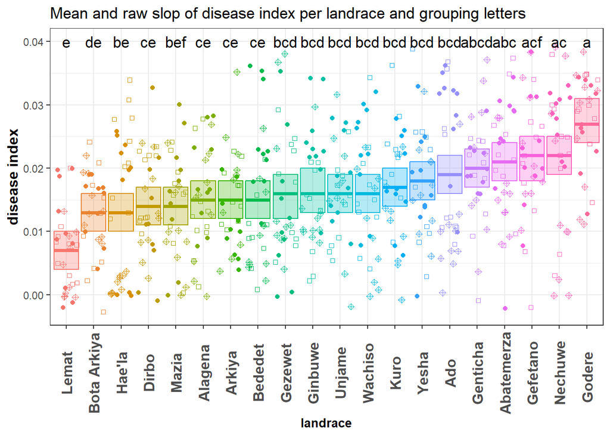

```r
#Generate plot of mean+confidence interval of slop with significance letters and raw data as jittered points##
ggplot(aes(x=landrace, y=slop_api, color=landrace),data=slop_cld) + ###Plot the origial disease index data
  geom_crossbar(data = slop_lm_cld, aes(x = landrace, y = mean, ymin = lower, ymax = upper,fill=landrace), alpha=0.3) +
  geom_jitter(aes(shape=block)) + ###with jitter overplotted, symbol shape defined by block
  scale_shape_manual(values=c(9, 19, 22,23))+
  geom_text(aes(x=landrace, y=0.04, label=Letters,size=10),color="black", data=slop_lm_cld)  +###Get the letters from cld_di_lmer
  #and write those to position y=-3
  labs(y="disease index") + #Y-Axis label
  ggtitle("Mean and raw slop of disease index per landrace and grouping letters") + #Title
  theme_bw()+
  theme(axis.title.x = element_text(face="bold", size=10), axis.text.x  =  element_text(angle=90, vjust=0.5, size=12,face = "bold"))+
  theme(axis.title.y= element_text(size = 12,face = "bold"))+
  theme(legend.position="none")
```

# 7. Survival Analysis

In the following plot all of the observations that are above the dotted line in the plot below are *dead*, at the day they cross that line. Those that never cross the line are alive until the end of observations, and are “right censored”, meaning that their event was not observed during the time this subject was observed.

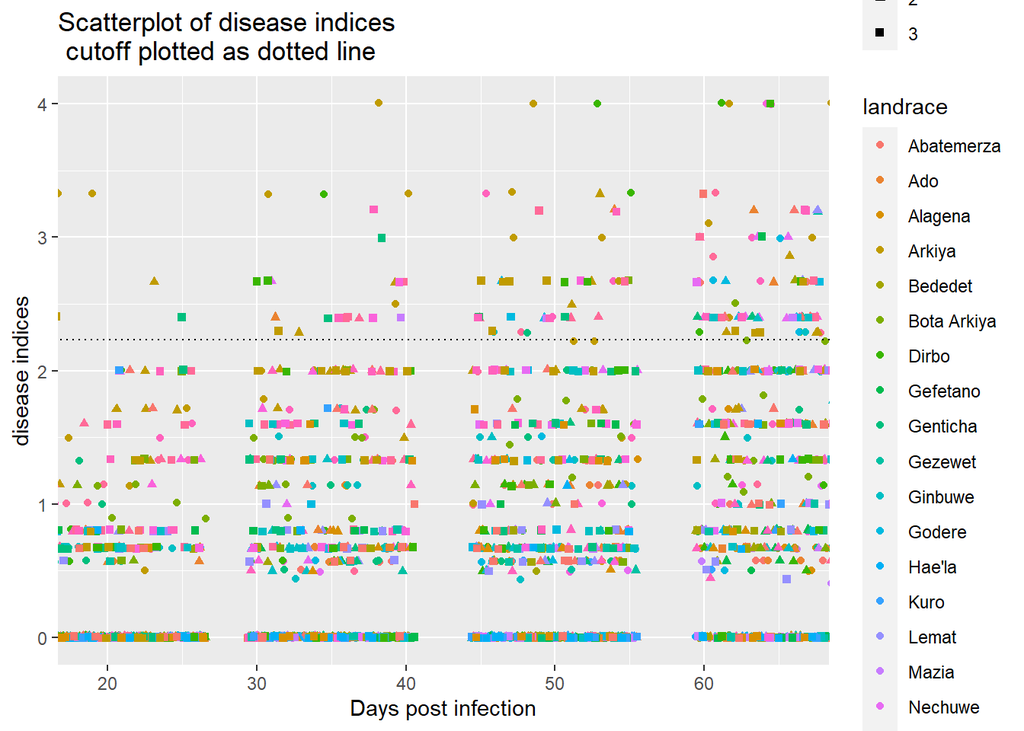

```r
cutoff <- c(2.23)
ggplot(data=enset_xvm_long) +
  geom_jitter(aes(x=dpi, y=di,color=landrace,shape=block)) +
  geom_segment(aes(x=0, xend=max(dpi)+0.5,y=cutoff, yend=cutoff), linetype="dotted") +
                  labs(x = "Days post infection",
                       y = "disease indices",
                       title="Scatterplot of disease indices\n cutoff plotted as dotted line") +
                  coord_cartesian(xlim=c(19,66))
```

```r
###Generate survival table
surv_from_di <- data.frame(Subject=enset_xvm_long$subject,
landrace=enset_xvm_long$landrace,
plant=enset_xvm_long$plant,
block=enset_xvm_long$block)
###Fill survival table based on the enset_xvm_long table. This generates warnings. These can be ignored and come from the min()
for (i in 1:max(enset_xvm_long$subject)) { #Go by subject
  dummy <- enset_xvm_long[enset_xvm_long$subject==i,] #generate dummy for the subject
  if (is.infinite(min(dummy$dpi[which(dummy$di >= cutoff)]))) { #If none of the di is greater than the cutoff (this is where warnings are generated, min on an empty object returns infinite and a warning!)
    surv_from_di$End[i] <- max(dummy$dpi) #Generate a  observation, censoring at the maximum dpi recorded
    surv_from_di$Death[i] <- 0 #Still alive, because it did not pass the cutoff
  } else { #If more than zero di are greater than the cutoff
    surv_from_di$End[i] <- min(dummy$dpi[which(dummy$di >= cutoff)]) #Use the lowest dpi where condition is met
    surv_from_di$Death[i] <- 1 #record as dead
  }
}
rm(dummy)
```

## 7.2 Kaplan-Meier estimates of survival

Kaplan-Meier estimates of survival are the basic tool of survival analysis. These can be estimated using the survfit function from the “survival” package.

```r
library(survival)
library(stringr)
library(tidyr)
surv_di_fit <- survfit(Surv(End, Death) ~landrace +strata(block), data=surv_from_di)
```

The survminer package provides the ggsurvplot() function. This works nicely on datasets with few treatments. However, for the data presented here, it is easier to initially generate a data frame that contains the fit and plot with “normal” ggplot2

```r
###Strata dummy generation, modified from kmiddleton / rexamples
strata_dummy <-NULL
for(i in 1:length(surv_di_fit$strata)){
      # add vector for one strata according to number of rows of strata
      strata_dummy <- c(strata_dummy, rep(names(surv_di_fit$strata)[i], surv_di_fit$strata[i]))
}
###Data frame generation inspired by a post by Hadley Wickham to the ggplot2 Googlegroup
surv_di_fit.df <- data.frame(
  time = surv_di_fit$time,
  n.risk = surv_di_fit$n.risk,
  n.event = surv_di_fit$n.event,
  surv = surv_di_fit$surv,
  strata = strata_dummy,
  upper = surv_di_fit$upper,
  lower = surv_di_fit$lower
)
zeros <- data.frame(time = 0, surv = 1, strata = names((surv_di_fit$strata)),
  upper = 1, lower = 1)

surv_di_fit.df <- plyr::rbind.fill(zeros, surv_di_fit.df) ###I dont want to load plyr because i guess it will interfere with dplyr...
rm(strata_dummy)
rm(zeros)

##The block and landrace columns are regenerated from the strata field, there are probably more elegant ways to do this

surv_di_fit.df$block <- as.factor( str_split_fixed(
  matrix( nrow=length(surv_di_fit.df$strata),ncol=2, unlist(strsplit(as.character(surv_di_fit.df$strata),", ")), byrow=T )[,2],"=",2)[,2])
surv_di_fit.df$landrace <- as.factor( str_split_fixed(
    matrix( nrow=length(surv_di_fit.df$strata),ncol=2, unlist(strsplit(as.character(surv_di_fit.df$strata),", ")), byrow=T )[,1],"=",2)[,2])
###End of data frame generation
```

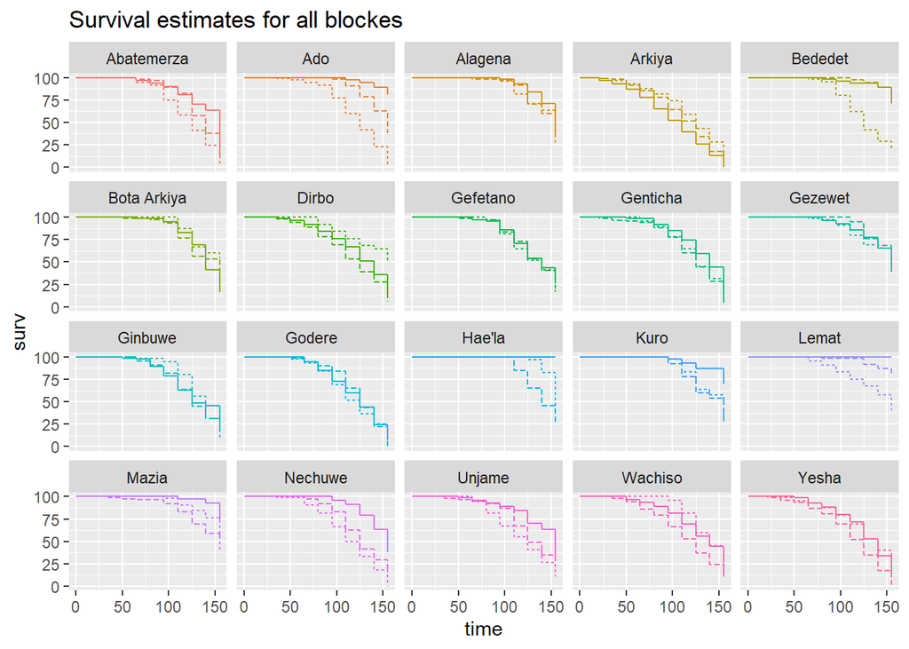

```r
###Start plotting
ggplot(surv_di_fit.df, aes(time, surv, colour = landrace)) +
  geom_step(aes(y = surv*100,linetype=block)) +
  facet_wrap(~landrace) +
  ggtitle("Survival estimates for all blockes")+
  theme(legend.position="none")
```

## 7.3 Cox-Proportional hazards and hazard ratios

Different approaches to survival analysis, are based on analysing the hazards. The hazard is the probability of experiencing an event at a given timepoint. Many hazard based analysis assume that hazards are proportional between treatments, meaning that they differ by a fixed factor. Hazards were strongly influenced by Cox and a basic model is the cox proportional hazards model.

```r
###Cox-Proportional hazards####
#Build model
srv_coxph <- coxph(Surv(End, Death) ~landrace + strata(block), data=surv_from_di)
summary(srv_coxph)
```

```
## Call:
## coxph(formula = Surv(End, Death) ~ landrace + strata(block),
##     data = surv_from_di)
##
##   n= 6000, number of events= 1786
##
##                          coef exp(coef)  se(coef)      z Pr(>|z|)
## landraceAdo         -0.466029  0.627489  0.154343 -3.019 0.002532 **
## landraceAlagena     -0.830802  0.435700  0.171872 -4.834 1.34e-06 ***
## landraceArkiya       0.622440  1.863469  0.121764  5.112 3.19e-07 ***
## landraceBededet     -0.906910  0.403770  0.174340 -5.202 1.97e-07 ***
## landraceBota Arkiya -0.574541  0.562963  0.157952 -3.637 0.000275 ***
## landraceDirbo        0.008100  1.008133  0.135945  0.060 0.952486
## landraceGefetano    -0.138165  0.870955  0.141245 -0.978 0.327978
## landraceGenticha     0.151447  1.163517  0.133143  1.137 0.255341
## landraceGezewet     -0.893940  0.409041  0.174314 -5.128 2.92e-07 ***
## landraceGinbuwe      0.001661  1.001663  0.137084  0.012 0.990331
## landraceGodere       0.406671  1.501810  0.127084  3.200 0.001374 **
## landraceHae'la      -1.301895  0.272016  0.201976 -6.446 1.15e-10 ***
## landraceKuro        -0.818899  0.440917  0.170735 -4.796 1.62e-06 ***
## landraceLemat       -1.470354  0.229844  0.212774 -6.910 4.83e-12 ***
## landraceMazia       -1.221370  0.294826  0.195242 -6.256 3.96e-10 ***
## landraceNechuwe      0.100755  1.106006  0.134460  0.749 0.453656
## landraceUnjame      -0.033591  0.966967  0.137726 -0.244 0.807313
## landraceWachiso      0.066963  1.069255  0.134996  0.496 0.619870
## landraceYesha        0.283377  1.327606  0.129522  2.188 0.028679 *
## ---
## Signif. codes:  0 '***' 0.001 '**' 0.01 '*' 0.05 '.' 0.1 ' ' 1
##
##                     exp(coef) exp(-coef) lower .95 upper .95
## landraceAdo            0.6275     1.5937    0.4637    0.8491
## landraceAlagena        0.4357     2.2952    0.3111    0.6102
## landraceArkiya         1.8635     0.5366    1.4678    2.3657
## landraceBededet        0.4038     2.4767    0.2869    0.5682
## landraceBota Arkiya    0.5630     1.7763    0.4131    0.7672
## landraceDirbo          1.0081     0.9919    0.7723    1.3159
## landraceGefetano       0.8710     1.1482    0.6603    1.1487
## landraceGenticha       1.1635     0.8595    0.8963    1.5104
## landraceGezewet        0.4090     2.4447    0.2907    0.5756
## landraceGinbuwe        1.0017     0.9983    0.7657    1.3104
## landraceGodere         1.5018     0.6659    1.1707    1.9266
## landraceHae'la         0.2720     3.6763    0.1831    0.4041
## landraceKuro           0.4409     2.2680    0.3155    0.6162
## landraceLemat          0.2298     4.3508    0.1515    0.3488
## landraceMazia          0.2948     3.3918    0.2011    0.4323
## landraceNechuwe        1.1060     0.9042    0.8498    1.4395
## landraceUnjame         0.9670     1.0342    0.7382    1.2666
## landraceWachiso        1.0693     0.9352    0.8207    1.3931
## landraceYesha          1.3276     0.7532    1.0300    1.7113
##
## Concordance= 0.681  (se = 0.008 )
## Likelihood ratio test= 524  on 19 df,   p=<2e-16
## Wald test            = 455  on 19 df,   p=<2e-16
## Score (logrank) test = 519.7  on 19 df,   p=<2e-16
```

```r
###Check porportionality of hazards
cox.zph(srv_coxph)
```

```
##          chisq df       p
## landrace  46.2 19 0.00046
## GLOBAL    46.2 19 0.00046
```

## 7.4 Hazard analysis using cox mixed model

```r
library("coxme")
cxm=coxme(Surv(End,Death)~landrace+(1|block),data = surv_from_di)
```

```r
anova(cxm)
```

```
## Analysis of Deviance Table
##  Cox model: response is Surv(End, Death)
## Terms added sequentially (first to last)
##
##          loglik  Chisq Df Pr(>|Chi|)
## NULL     -13200
## landrace -12918 564.25 19  < 2.2e-16 ***
## ---
## Signif. codes:  0 '***' 0.001 '**' 0.01 '*' 0.05 '.' 0.1 ' ' 1
```

```r
summary(cxm)
```

```
## Cox mixed-effects model fit by maximum likelihood
##   Data: surv_from_di
##   events, n = 1786, 6000
##   Iterations= 10 63
##                     NULL Integrated    Fitted
## Log-likelihood -13200.08  -12917.96 -12913.82
##
##                    Chisq    df p    AIC    BIC
## Integrated loglik 564.25 20.00 0 524.25 414.49
##  Penalized loglik 572.53 20.92 0 530.70 415.91
##
## Model:  Surv(End, Death) ~ landrace + (1 | block)
## Fixed coefficients
##                             coef exp(coef)  se(coef)     z       p
## landraceAdo         -0.467674676 0.6264573 0.1543320 -3.03 2.4e-03
## landraceAlagena     -0.833558655 0.4345003 0.1718634 -4.85 1.2e-06
## landraceArkiya       0.623605228 1.8656420 0.1217347  5.12 3.0e-07
## landraceBededet     -0.908378038 0.4031776 0.1743350 -5.21 1.9e-07
## landraceBota Arkiya -0.573039654 0.5638090 0.1579078 -3.63 2.8e-04
## landraceDirbo        0.012586801 1.0126663 0.1358882  0.09 9.3e-01
## landraceGefetano    -0.137556227 0.8714853 0.1412428 -0.97 3.3e-01
## landraceGenticha     0.151899164 1.1640429 0.1331242  1.14 2.5e-01
## landraceGezewet     -0.892740104 0.4095321 0.1742951 -5.12 3.0e-07
## landraceGinbuwe      0.000843961 1.0008443 0.1370748  0.01 1.0e+00
## landraceGodere       0.408629546 1.5047542 0.1270772  3.22 1.3e-03
## landraceHae'la      -1.302488708 0.2718544 0.2019726 -6.45 1.1e-10
## landraceKuro        -0.817656256 0.4414651 0.1707285 -4.79 1.7e-06
## landraceLemat       -1.470869099 0.2297257 0.2127743 -6.91 4.8e-12
## landraceMazia       -1.223905694 0.2940793 0.1952404 -6.27 3.6e-10
## landraceNechuwe      0.097300329 1.1021913 0.1344425  0.72 4.7e-01
## landraceUnjame      -0.035060086 0.9655474 0.1377204 -0.25 8.0e-01
## landraceWachiso      0.067332369 1.0696509 0.1349924  0.50 6.2e-01
## landraceYesha        0.285742581 1.3307499 0.1295090  2.21 2.7e-02
##
## Random effects
##  Group Variable  Std Dev    Variance
##  block Intercept 0.19854484 0.03942005
```

```r
cxme_ph=cld(glht(cxm,linfct=mcp(landrace="Tukey")))
cxme_ph.df=data.frame(cbind(levels(surv_from_di$landrace),cxme_ph$mcletters$Letters))
colnames(cxme_ph.df)=c("Landrace","Letters")
rownames(cxme_ph.df)=NULL
cxme_ph.df
```

```
##       Landrace Letters
## 1   Abatemerza      ab
## 2          Ado      ac
## 3      Alagena      cd
## 4       Arkiya       e
## 5      Bededet      cd
## 6  Bota Arkiya     cfg
## 7        Dirbo      ab
## 8     Gefetano     afh
## 9     Genticha      bh
## 10     Gezewet      cd
## 11     Ginbuwe      ab
## 12    Godere        be
## 13      Hae'la      dg
## 14        Kuro      cd
## 15       Lemat       d
## 16       Mazia      dg
## 17     Nechuwe      bh
## 18      Unjame     abf
## 19     Wachiso      bh
## 20       Yesha     beh
```

```r
write.csv(cxme_ph.df,file = "cxme_ph.df.csv")
```

## 7.5 Analysis of survival curves and fits

Comparing the Kaplan-Meier survival estimates can be done in different ways. Here non-parametric log-rank testing and parametric survival regression will be used.

### Logrank testing

The below produces all pairwise comparisons of the Kaplan Meier estimate of survival using a logrank test.

```r
###Make a table of pairwise chisq pvalues, for the logrank test.
#Based on a post to the R Mailing list by T. Therneau
pw_logrank_test_type <- 0 ###0 for logrank, 1 for peto and peto
pw_logrank <- matrix(0., nlevels(surv_from_di$landrace),nlevels(surv_from_di$landrace))
for (i in 1:nlevels(surv_from_di$landrace)) {
  for (j in (1:nlevels(surv_from_di$landrace))[-i]) {
    datasubset <- droplevels(subset( surv_from_di,
                                     surv_from_di$landrace %in% (unique(surv_from_di$landrace))[c(i,j)]))
    temp <- survdiff(Surv(End, Death)~landrace+strata(block), data=datasubset, rho=pw_logrank_test_type)

    pw_logrank[i,j] <- pchisq(temp$chisq, df=1, lower=F) ##df will always be 1 because this is pairwise
  }
}
colnames(pw_logrank) <- levels(surv_from_di$landrace)
rownames(pw_logrank) <- levels(surv_from_di$landrace)
#Make dummy adjustment table
pw_logrank_adjBon <- pw_logrank
#Fill adjusted pvalue table.
for (i in 1:ncol(pw_logrank)) {
  pw_logrank_adjBon[,i] <- cbind(p.adjust(pw_logrank[,i], method="bonferroni"))
}
stargazer::stargazer(pw_logrank_adjBon,type="text",title="Pairwise Chisq p-values (Bonferroni adjusted)")
```

```
##
## Pairwise Chisq p-values (Bonferroni adjusted)
## ====================================================================================================================================================================================
##             Abatemerza   Ado   Alagena Arkiya  Bededet Bota Arkiya  Dirbo  Gefetano Genticha Gezewet Ginbuwe Godere  Hae'la   Kuro    Lemat   Mazia  Nechuwe Unjame  Wachiso  Yesha
## ------------------------------------------------------------------------------------------------------------------------------------------------------------------------------------
## Abatemerza      0         0       0       0       0         1         0       0        0      0.155     1       0     0.117  0.0001   0.278     0       0       0     0.001   0.324
## Ado             0         0       1       1       1         0         1     0.262      1     0.00000    0       1    0.00000  0.001  0.00000    1       1    0.00003 0.0003  0.00000
## Alagena         0         1       0       1       1         0         1     0.021    0.380   0.00001    0       1    0.00002  0.040  0.00001    1       1    0.00000  0.010  0.00001
## Arkiya          0         1       1       0       1         0         1     0.103      1     0.00000    0       1    0.00000  0.012  0.00000    1       1    0.00001  0.002  0.00000
## Bededet         0         1       1       1       0         0         1     0.187      1     0.00000    0       1    0.00000  0.003  0.00000    1       1    0.00002  0.001  0.00000
## Bota Arkiya     1         0       0       0       0         0         0       0        0      0.544     1       0     0.407  0.0003     1       0       0       0     0.005     1
## Dirbo           0         1       1       1       1         0         0     0.001    0.033   0.0004  0.00000    1     0.001   0.440  0.0002   0.865     1       0     0.132  0.0002
## Gefetano        0       0.262   0.021   0.103   0.187       0       0.001     0        1        0       0     0.010     0       0       0     0.705   0.032   0.276     0       0
## Genticha        0         1     0.380     1       1         0       0.033     1        0        0       0     0.244     0    0.00000    0       1     0.527   0.018  0.00000    0
## Gezewet       0.155    0.00000 0.00001 0.00000 0.00000    0.544    0.0004     0        0        0       1    0.00001    1     0.760     1       0    0.00000    0       1       1
## Ginbuwe         1         0       0       0       0         1      0.00000    0        0        1       0       0       1     0.003     1       0       0       0     0.024     1
## Godere          0         1       1       1       1         0         1     0.010    0.244   0.00001    0       0    0.00001  0.033  0.00000    1       1    0.00000  0.009  0.00000
## Hae'la        0.117    0.00000 0.00002 0.00000 0.00000    0.407     0.001     0        0        1       1    0.00001    0       1       1    0.00000 0.00001    0       1       1
## Kuro          0.0001    0.001   0.040   0.012   0.003    0.0003     0.440     0     0.00000   0.760   0.003   0.033     1       0     0.428  0.0003   0.021     0       1     0.502
## Lemat         0.278    0.00000 0.00001 0.00000 0.00000      1      0.0002     0        0        1       1    0.00000    1     0.428     0       0    0.00000    0       1       1
## Mazia           0         1       1       1       1         0       0.865   0.705      1        0       0       1    0.00000 0.0003     0       0       1    0.0002  0.00004    0
## Nechuwe         0         1       1       1       1         0         1     0.032    0.527   0.00000    0       1    0.00001  0.021  0.00000    1       0    0.00000  0.005  0.00000
## Unjame          0      0.00003 0.00000 0.00001 0.00002      0         0     0.276    0.018      0       0    0.00000    0       0       0    0.0002  0.00000    0       0       0
## Wachiso       0.001    0.0003   0.010   0.002   0.001     0.005     0.132     0     0.00000     1     0.024   0.009     1       1       1    0.00004  0.005     0       0       1
## Yesha         0.324    0.00000 0.00001 0.00000 0.00000      1      0.0002     0        0        1       1    0.00000    1     0.502     1       0    0.00000    0       1       0
## ------------------------------------------------------------------------------------------------------------------------------------------------------------------------------------
```

Hazards are found to be non-proportional, as is observed here, it might be a good idea to perform survival regression analysis, or pairwise log-rank testing (see below) instead of hazard ratio tests.

### Regressions

Generally a survival regression does not assume proportionality of hazards. A survival regression is fit to a distribution, defined by dist=““.

```r
library(rms)
####Survival Regression###
###This is done using functions from rms.
###psm is a survival::survreg wrapper. but the output is more handle-able for some other functions.
ddist <- datadist(surv_from_di)
options(datadist="ddist")
psurv_gaus <- psm(Surv(End, Death) ~landrace, data=surv_from_di, dist="gaussian")
psurv_logistic <- psm(Surv(End, Death) ~landrace, data=surv_from_di, dist="logistic")
psurv_lnorm <- psm(Surv(End, Death) ~landrace, data=surv_from_di, dist="lognormal")
psurv_wei <- psm(Surv(End, Death) ~landrace, data=surv_from_di, dist="weibull")
###Same with survreg()
s_reg_gaus <- survreg(Surv(End, Death) ~landrace, data=surv_from_di, dist="gaussian")
s_reg_logistic <- survreg(Surv(End, Death) ~landrace, data=surv_from_di, dist="logistic")
s_reg_lnorm <- survreg(Surv(End, Death) ~landrace, data=surv_from_di, dist="lognormal")
s_reg_wei <- survreg(Surv(End, Death) ~landrace, data=surv_from_di, dist="weibull")
aic.scores.psurv <- rbind(
  extractAIC(psurv_wei),
  extractAIC(psurv_gaus),
  extractAIC(psurv_logistic),
  extractAIC(psurv_lnorm))
###Make useable AIC table
rownames(aic.scores.psurv) <- c("Weibull", "Gaussian", "Logist", "Lognorm")
colnames(aic.scores.psurv) <- c("df", "AIC")
stargazer::stargazer(aic.scores.psurv,type="text",title="AIC Scores")
```

```
##
## AIC Scores
## ======================
##          df    AIC
## ----------------------
## Weibull  21 19,216.010
## Gaussian 21 19,176.710
## Logist   21 19,220.760
## Lognorm  21 19,646.700
## ----------------------
```

```r
###Call table
```

From the table above, the model with the lowest AIC score can be chosen. For this analysis, Gaussian model will be the choice for analysis. Then, one can inspect this model for significant differences.

### Plotting of parametric survival regression

It is possible, but not really easy, to plot the curves generated using parametric survival regression. These curves are the result of fitting the data to a distribution in the earlier section. Doing this in a manner that is compatible with ggplot2 requires a nice dataframe. Below is code to generate plots of the KM estimates per block and the generated fit. This is performed for the four distributions above, and can be adapted to different distributions if necessary.

```r
###Step 1, extract the coefficients. These are relative to landrace1 because landrace is treatment contrasted.

for (i in 1:nlevels(surv_di_fit.df$landrace)) { #For loop through landraces
  if(i==1) { #landrace1 is relative to itself, so no change
  coef_wei <- list()
  coef_logistic <- list()
  coef_gaus <- list()
  coef_lnorm <- list()
  coef_wei[i] <- coef(s_reg_wei)[i]
  coef_logistic[i] <- coef(s_reg_logistic)[i]
  coef_gaus[i] <- coef(s_reg_gaus)[i]
  coef_lnorm[i] <- coef(s_reg_lnorm)[i]
  } else { ###Other landraces are relative to 1
  coef_wei[i] <- coef(s_reg_wei)[1] + coef(s_reg_wei)[i]
  coef_logistic[i] <- coef(s_reg_logistic)[1] + coef(s_reg_logistic)[i]
  coef_gaus[i] <- coef(s_reg_gaus)[1] + coef(s_reg_gaus)[i]
  coef_lnorm[i] <- coef(s_reg_lnorm)[1] + coef(s_reg_lnorm)[i]
  }
}
##Step 2
####Store the coefficients and the scale in a new data frame, of parameters
### Keep in mind that survreg.distributions$weibull is different from rweibull, hence the difference in names.
sregparams <- data.frame(
  landrace = rep(levels(surv_from_di$landrace),4 ), #Fill with landraces
  scale.wei = exp(unlist(coef_wei)), #weibull fit scale parameters
  scale.logistic = rep(s_reg_logistic$scale, nlevels(surv_from_di$landrace)), #fill with logis scales
  scale.gaus = rep(s_reg_gaus$scale, nlevels(surv_from_di$landrace)), #fill with gaus scales
  scale.lnorm = rep(s_reg_lnorm$scale, nlevels(surv_from_di$landrace)), #fill with lnorm scale
  shape.wei =  rep(1/s_reg_wei$scale, nlevels(surv_from_di$landrace)), #shape for weibull
  shape.logistic = unlist(coef_logistic), #shape for logistic
  shape.gaus =  unlist(coef_gaus), #shape for gaus
  shape.lnorm =   unlist(coef_lnorm) #shape for lnorm
  )
##Step 3
###Calculate the "daily" value of each curve
for (i in 1:nlevels(surv_di_fit.df$landrace)){
  if(i==1) {
    wei <- list()
    logis <- list()
    gaus <- list()
    lnorm <- list()
  }
  x <- levels(surv_di_fit.df$landrace)[i]
  n <- c(1:max(surv_from_di$End))
  data <- filter(sregparams, landrace==x)
  time <- n
  wei <- cbind(wei, pweibull(
    q=n,
    scale=data$scale.wei,
    shape=data$shape.wei,
    lower.tail=FALSE))
  logis <- cbind(logis,plogis(
    q=n,
    scale=data$scale.logistic,
    location=data$shape.logistic,
    lower.tail=FALSE  ))
  gaus <- cbind(gaus,pnorm(
   q=n,
   sd=data$scale.gaus,
   mean=data$shape.gaus,
   lower.tail = F))
  lnorm <- cbind(lnorm, plnorm(
    q=n,
    sd=data$scale.lnorm,
    mean=data$shape.lnorm,
    lower.tail=F))
}

##Step 4
###Put all the curves into a data.frame that contains information on "time" and also "landrace", for compatibility with other data.frames
sreg_curves <- data.frame(
  wei.sreg = cbind(unlist(wei)),
  logis.sreg = cbind(unlist(logis)),
  gaus.sreg = cbind(unlist(gaus)),
  lnorm.sreg = cbind(unlist(lnorm)),
  landrace = rep(unlist(levels(surv_di_fit.df$landrace)),each=max(surv_from_di$End)),
  time = rep(c(1:max(surv_from_di$End)), nlevels(surv_di_fit.df$landrace))
)
##Step 5
###Turn that data.frame into a long data.frame (not used here but could be handy.)
sreg_long <- sreg_curves %>%
  group_by(landrace) %>%
  gather(key="distribution", value = "value", logis.sreg, wei.sreg, gaus.sreg, lnorm.sreg )
sreg_long$distribution <- as.factor(sreg_long$distribution)
##Levels: gaus.sreg lnorm.sreg logis.sreg wei.sreg
levels(sreg_long$distribution) <- c("Gaussian","Lognormal","Loglogistic","Weibull")
```

Now, these can be plotted and inspected visually..

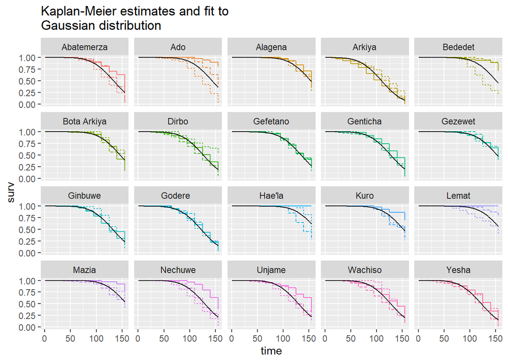

```r
###Plot of KM+Gaussian
  ggplot(surv_di_fit.df, aes(time, surv, colour = landrace)) +
    geom_step(aes(linetype=block)) +
    #geom_smooth(aes(linetype=block)) +
    geom_line(data=sreg_curves,aes(y=gaus.sreg),color="black") +
    facet_wrap(~landrace) +
    ggtitle("Kaplan-Meier estimates and fit to\nGaussian distribution")+
    theme(legend.position = "none")
```

# 8. Manuscript figures

The following scripts was used to generate figures in the manuscript.  
## Fig 5: Plot of actual AUDPS per landrace and, mean and CI of AUDPS

```r
###For the purpose of visualization calculate summaries across all replicates
di_summary.noblock <- enset_xvm_long %>% group_by(plant, landrace, dpi) %>% summarise(mean(di),sd(di),sd(di)/sqrt(length(di)))
colnames(di_summary.noblock) <- c("plant", "landrace", "dpi", "mean", "sd", "se")

###Generate mean and standard deviation of disease index using the pipe function ( %>% ).
di_summary <- enset_xvm_long %>% group_by(plant, landrace, block, dpi) %>% summarise(mean(di),sd(di),sd(di)/sqrt(length(di)))
colnames(di_summary) <- c("plant", "landrace", "block", "dpi", "mean", "sd", "se") ###Assign correct columnnames

####Fig7a: Plot the actual areas per landrace
Fig5a <-
  ggplot(filter(di_summary),aes(x=dpi,y=mean)) + ###Use data di_summary
  geom_area(aes(color=block,fill=block))+
  scale_fill_manual(values = c("gray1","#999999","gray50"))+
#geom_line(aes(linetype=block)) +#show line by each block
#aes(x=dpi,y=mean,color=landrace) + ###Color by landrace, specify x and y.
#geom_area(aes(fill=landrace),position="identity",alpha=0.15) + ###Area plot, colored by landrace
facet_wrap(~landrace) + ###One plot per landrace
  labs(x = "Days after infection", y = "Mean disease index") + #Labels
  ggtitle("5A) Area under disease progression of landraces across blocks")+
  theme_bw()+
  theme(strip.text.x = element_text(size = 12,face = "bold"),
        axis.text.x =  element_text(size = 11,face = "bold"),
        axis.title.x = element_text(size = 12,face = "bold"),
        axis.title.y = element_text(size = 12,face = "bold"),
        axis.text.y =  element_text(size = 11,face = "bold"),
        legend.position = "none")

####Fig5b: Plot mean and confidence interval AUDPS per landrace###

color_fill_gray <- c("#999999","#999999","#999999","#999999","#999999",                               "#999999","#999999","#999999","#999999","#999999", "#999999","#999999","#999999","#999999","#999999",
         "#999999","#999999","#999999","#999999","#999999") # fill grey color for all landraces

####Generate plot of meanCI of AUDPS with significance letters and raw data as jittered points
cld_audps=cld_audps[order(cld_audps$audps),]# reorder by mean value to cheat ggplot
cld_audps$landrace =factor(cld_audps$landrace,levels = cld_audps$landrace)#put factors in level

Fig5b<-
  ggplot(aes(x=landrace, y=audps, fill=landrace),data=audps_data__cld) + ###Plot the audps_data
  scale_shape_manual(values=c(9, 19, 22))+
  geom_crossbar(data = cld_audps, aes(x = landrace, y = audps, ymin = lower, ymax = upper,fill=landrace), alpha=0.3,fill="gray") +
  scale_fill_manual(values = color_fill_gray)+
  geom_jitter(aes(shape=block),data = audps_data__cld) + ###with jitter overplotted, symbol shape defined by block
  geom_text(aes(x=landrace, y=-20, label=aud_let),color="black", size=3.5, data=audps_data__cld) + ###Get the letters from auc_cld
  #and write those to position y=-3
  labs(y="AUDPS") + #Y-Axis label
  ggtitle("5B) Mean and raw audps values per landrace and grouping letters") +#Title
  theme_bw()+
  theme(axis.title.y = element_text(face="bold", size=12),
        axis.title.x = element_blank(),
        axis.text.y = element_text(size = 11,face = "bold"),
        axis.text.x  = element_text(angle=90, vjust=0.5, size=12,face = "bold"),
        legend.position="none")

library(grid)
pushViewport(viewport(layout= grid.layout(nrow=1, ncol=2)))
print(Fig5a, vp = viewport(layout.pos.row = 1, layout.pos.col = 1))
print(Fig5b, vp = viewport(layout.pos.row = 1, layout.pos.col = 2))
### Fig5 done ###
# This figure might not appear in below and can be view running in R console on non-Rmakrdown Rscript file.
```

##Fig 6 - Survival Regression

```r
# Script from Schandry (2017) used with modfication
survfit_to_df <- function(x) {
  strata_dummy <-NULL
  for(i in 1:length(x$strata)){
    # add vector for one strata according to number of rows of strata
    strata_dummy <- c(strata_dummy, rep(names(x$strata)[i], x$strata[i]))
  }
  #make x.df from x..
  x.df <- data.frame(
    time = x$time,
    n.risk = x$n.risk,
    n.event = x$n.event,
    surv = x$surv,
    strata = strata_dummy,
    upper = x$upper,
    lower = x$lower
  )
  zeros <- data.frame(time = 0, surv = 1, strata = names((x$strata)),
                      upper = 1, lower = 1)
  x.df <- plyr::rbind.fill(zeros, x.df)
  rm(strata_dummy)
  rm(zeros)
  return(x.df)
}

###Generate intermediate survival tables##
surv_table1 <- data.frame(subject=enset_xvm_long$subject,
                          landrace=enset_xvm_long$landrace,
                          plant=enset_xvm_long$plant,
                          block=enset_xvm_long$block)
###Fill survival table based on the enset_xvm_long table. This generates warnings. These can be ignored and come from the min()
cutoff <- c(2.23)
for (i in 1:max(enset_xvm_long$subject)) { #Go by subject
  dummy <- enset_xvm_long[enset_xvm_long$subject==i,] #generate dummy for the subject
  if (is.infinite(min(dummy$dpi[which(dummy$di >= cutoff)]))) { #If none of the di is greater than the cutoff (this is where warnings are generated, min on an empty object returns infinite!)
    surv_table1$End[i] <- max(dummy$dpi) #Generate a  observation, censoring at the maximum dpi recorded
    surv_table1$Death[i] <- 0 #Still alive, because it did not pass the cutoff
  } else { #If more than zero di are greater than the cutoff
    surv_table1$End[i] <- min(dummy$dpi[which(dummy$di >= cutoff)]) #Use the lowest dpi where condition is met
    surv_table1$Death[i] <- 1 #record as dead
  }
}
###Make survfits with the four survival tables..
surv_di_fit1 <- with(surv_table1, survfit(Surv(End, Death) ~landrace +strata(block), data=surv_from_di))

###Make survfits into surv_df
surv_di_fit1.df <- survfit_to_df(surv_di_fit1)

###However the strata field still needs to be split manually....
surv_di_fit1.df$block <- as.factor( str_split_fixed(
  matrix( nrow=length(surv_di_fit1.df$strata),ncol=2, unlist(strsplit(as.character(surv_di_fit1.df$strata),", ")), byrow=T )[,2],"=",2)[,2])
surv_di_fit1.df$landrace <- as.factor( str_split_fixed(
  matrix( nrow=length(surv_di_fit1.df$strata),ncol=2, unlist(strsplit(as.character(surv_di_fit1.df$strata),", ")), byrow=T )[,1],"=",2)[,2])
###End of intermediate table generation##

###Landraces that showed non-significant coxme hazard ration were removed.

surv_landraces0=c("Ado", "Alagena", "Arkia", "Bededet", "Bota Arkia",
                  "Gezewet",  "Godere  ", "Hae'la", "Kuro", "Lemat", "Mazia","Yesha")


kmdata <- filter(surv_di_fit1.df, landrace %in% surv_landraces0)
curvdata <- filter(sreg_curves, landrace %in% surv_landraces0)
#Labels

###Plot of KM+Gaussian
Fig6a <- ggplot(kmdata, aes(time, surv, colour = landrace)) +
  geom_step(aes(linetype=block)) +
  geom_line(data=curvdata,aes(y=gaus.sreg),color="black") +
  facet_wrap(~landrace) + theme(legend.position="none")+
  ggtitle("Fig 6A)")+
  theme_bw()+
  labs(x = "Days post infection", y = "Fraction of plants alive") +
  theme(legend.position="none")+
  theme(axis.title.x = element_text(size = 12,face = "bold"),
        axis.title.y = element_text(size = 12,face = "bold"),
        axis.text.x = element_text(size = 8,face = "bold"),
        axis.text.y = element_text(size = 8,face = "bold"),
        strip.text = element_text(size = 12))


cb_palette <- c("yellow", "darkorchid", "red", "darkgrey", "#CDCD00",
                "#CDCD00", "peachpuff", "#228B22","dodgerblue4","#54FF9F",
                "paleturquoise2","indianred")

Fig6b <- ggplot(data=filter(surv_di_fit1.df), aes(x=time, y=surv,color=landrace))+
  #geom_step(aes(linetype=block),alpha=1)  +
  geom_line(data=curvdata,
            aes(y=lnorm.sreg,color=landrace),  size=1,  alpha=1) +
  scale_color_manual(values=cb_palette)+
  geom_point(data=curvdata,aes(y=lnorm.sreg,shape=landrace))+
  scale_shape_manual(values = c(0:5,8,9,11,25,15,16))+
  labs(x="Days post infection",
       y="Estimated survival",
       title=("Fig 6B)")) +
  coord_cartesian(xlim=c(54,155)) +
  scale_x_continuous(breaks=seq(50, 155, 15))+
  #labs(color="Legend")
  theme_bw()+
  theme(legend.position=c(0.01,1),
        legend.justification=c(0,1.6),
        legend.text = element_text(size = 12),
        legend.title = element_blank(),
        axis.title.x = element_text(size = 12,face = "bold"),
        axis.title.y = element_text(size = 12,face = "bold"),
        axis.text.x = element_text(size = 8,face = "bold"),
        axis.text.y = element_text(size = 8,face = "bold"))


pushViewport(viewport(layout= grid.layout(nrow=1, ncol=2)))
print(Fig6a, vp = viewport(layout.pos.row = 1, layout.pos.col = 1))
print(Fig6b, vp = viewport(layout.pos.row = 1, layout.pos.col = 2))
# This figure might not appear in below and can be view running in R console on non-Rmakrdown Rscript file.
####clear device
```

```r
dev.off()
```